# EP06

# ANOVA para muestras correlacionadas

## Introducción

```r
# Importar librerias
library("DT")
library(dplyr)
library(ggpubr)
library(ez)
library(emmeans)
```

```r
# Se leen los datos
data <- read.csv("EP06 Datos.csv")
```

Un equipo de investigadores del área de interacción humano-información está estudiando si el área temática y el nivel de dificultad del problema de información influyen en el tiempo (en segundos) que toma un usuario en formular una consulta de búsqueda para resolver dicho problema. Para ello, han reclutado a un grupo de participantes voluntarios, asignados aleatoriamente a distintos grupos. Cada participante debe resolver tres problemas de información con diferentes niveles de dificultad: baja, media y alta. A su vez, cada grupo debe resolver problemas relacionados a una temática diferente. Los datos recolectados contemplan las siguientes variables:

```r
Variables <- names(data)
Descripción <- c("identificador único de cada participante.", "Área temática de los problemas que el participante debe responder. Variable categórica con los niveles Arquitectura, Biología, Computación, Economía, Física, Leyes, Literatura, Matemáticas, Música, Pedagogía, Psicología, Química.", "Nivel de dificultad del problema resuelto. Variable categórica con los niveles Baja, Media y Alta.", "Tiempo, en segundos, que toma al participante formular la consulta.")

Tabla_variables <- data.frame(Variables, Descripción)
datatable(Tabla_variables,
          options = list(pageLength = 4),
          caption = "Tabla de descripción de variables")
```

|  | Variables | Descripción |
| --- | --- | --- |
| 1 | id | identificador único de cada participante. |
| 2 | area | Área temática de los problemas que el participante debe responder. Variable categórica con los niveles Arquitectura, Biología, Computación, Economía, Física, Leyes, Literatura, Matemáticas, Música, Pe… |
| 3 | dificultad | Nivel de dificultad del problema resuelto. Variable categórica con los niveles Baja, Media y Alta. |
| 4 | tiempo | Tiempo, en segundos, que toma al participante formular la consulta. |

En este momento, los investigadores buscan determinar si existen diferencias en el tiempo que tardan los usuarios en formular consultas para problemas con diferente nivel de dificultad en el área de economía.

## Hipótesis

Con la pregunta planteada, se sabe que se deben examinar los tiempos de los usuarios en formular consultas en el área de economía, es un diseño con pruebas repetidas, pues un usuario es medido 3 veces, una en cada dificultad, aparte se puede considerar el tiempo como una variable dependiente, que es dependiente del área y la dificultad de la consulta. siendo estas últimas variables independientes.

Para resolver la pregunta se plantean las siguientes hipótesis:

- $H_0$: No existe diferencia significativa en el tiempo que tardan los usuarios en formular consultas.
- $H_a$: Existe diferencia significativa en el tiempo que tardan los usuarios en formular consultas.

## Condiciones

```r
# Filtrar por área de economía
data_filter <- data |>
  filter(area == "Economía")
```

Para evaluar los datos y verificar las hipótesis se realizará una prueba ANOVA para muestras correlacionadas, pues lo datos siguen un diseño de muestras repetidas, al evaluar para cada participante 3 dificultades en consultas, para ello se verifican las siguientes condiciones:

- La escala con que se mide la variable dependiente tiene las propiedades de una escala de intervalos iguales. Esta condición se cumple pues la variable de tiempo es una escala física estandarizado por lo cual se considera una escala de intervalos iguales.
- Las observaciones son independientes al interior de cada muestra. El enunciado da la información de que los participantes fueron asignaos aleatoriamente a los distintos grupos (muestras), por lo que podemos suponer que los resultados de un participante no dependen de otros participantes.
- Se puede suponer razonablemente que la(s) población(es) de origen sigue(n) una distribución normal: para ello realizamos gráficos Q-Q para cada dificultad.

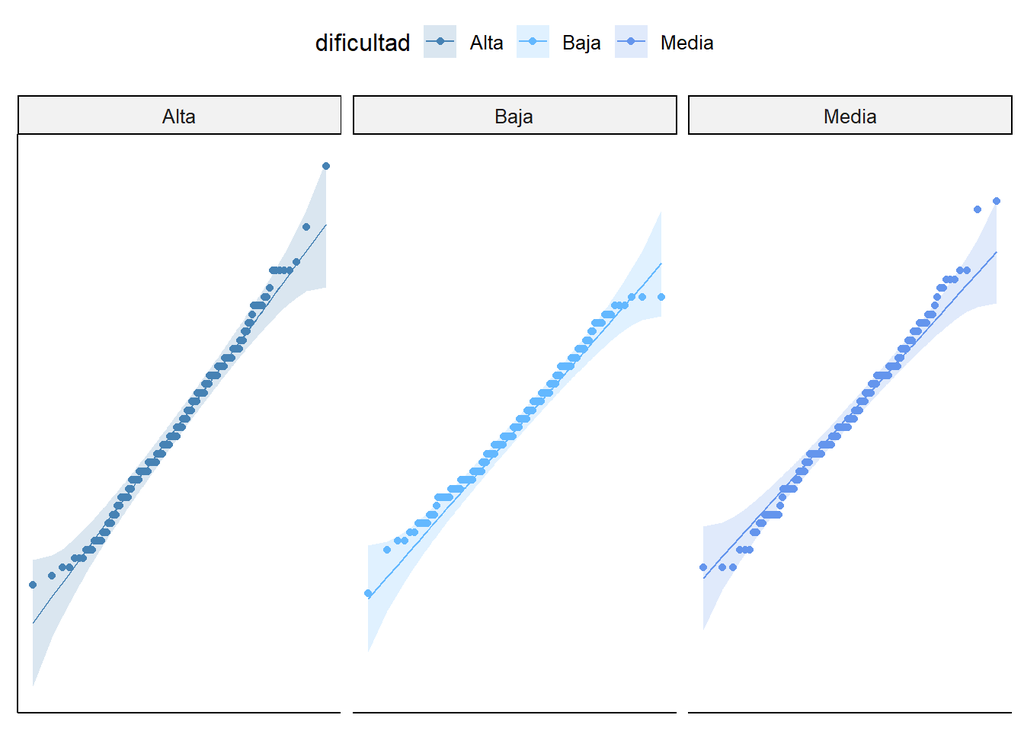

```r
g1 <- ggqqplot (data_filter, x = "tiempo", y = "dificultad",
color = "dificultad", alpha = 0.7,
palette = c("steelblue", "steelblue1", "cornflowerblue", "steelblue4") )
g1 <- g1 + facet_wrap(~ dificultad)
g1 <- g1 + rremove ("x.ticks") + rremove ("x.text")
g1 <- g1 + rremove ("y.ticks") + rremove ("y.text")
g1 <- g1 + rremove ("axis.title")
print (g1)
```

La mayor parte de los datos se encuentran dentro del intervalo de confianza, a excepción de algunos valores atípicos alejados de la frontera, por ello se considerará un alfa más exigente $\alpha=0.01$ al momento de realizar el test.

Aparte, verificamos nuestro análisis de los gráficos con el Test de Shapiro-Wilk:

```r
baja <- data_filter |>
  filter(dificultad == "Baja")
shapiro.test(baja$tiempo)
```

```
##
##  Shapiro-Wilk normality test
##
## data:  baja$tiempo
## W = 0.9905, p-value = 0.2111
```

```r
media <- data_filter |>
  filter(dificultad == "Media")
shapiro.test(media$tiempo)
```

```
##
##  Shapiro-Wilk normality test
##
## data:  media$tiempo
## W = 0.98957, p-value = 0.1543
```

```r
alta <- data_filter |>
  filter(dificultad == "Alta")
shapiro.test(alta$tiempo)
```

```
##
##  Shapiro-Wilk normality test
##
## data:  alta$tiempo
## W = 0.99002, p-value = 0.1797
```

Los resultados de los test por cada dificultad dan por resultado un $p>0.05$ por lo que no hay suficiente evidencia para descartar que los datos sigan una distribución normal.

- La última condición es que la matriz de varianzas-covarianzas sea esférica, esto se verificará durante el test, ya que incluye una prueba auxiliar para verificar esta condición.

## Test ANOVA para muestras correlacionadas

Con las condiciones ya verificadas y una pendiente, se procede a realizar el test.

```r
prueba_ez <- ezANOVA(data=data_filter, dv=tiempo, wid = id, within=dificultad)
print(prueba_ez)
```

```
## $ANOVA
##       Effect DFn DFd        F         p p<.05         ges
## 2 dificultad   2 398 1.343258 0.2621746       0.004607831
##
## $`Mauchly's Test for Sphericity`
##       Effect         W         p p<.05
## 2 dificultad 0.9775284 0.1053921
##
## $`Sphericity Corrections`
##       Effect       GGe    p[GG] p[GG]<.05       HFe     p[HF] p[HF]<.05
## 2 dificultad 0.9780223 0.262083           0.9876195 0.2621264
```

Los resultados son:

- Se cumple que la matriz de varianzas-covarianzas sea esférica, pues la prueba de esfericidad de Mauchly da un $p>0.05$, por lo que no existe evidencia suficiente para rechazar la hipótesis de que se cumpla esta condición.
- El test de ANOVA para muestras correlacionadas tiene un $p>0.01$ que fue el valor establecido debido a los valores atípicos, significando que no existen suficiente evidencia para rechazar la hipótesis nula sobre que no existe diferencia significativa en el tiempo que tardan los usuarios en formular consultas.

Según los resultados del test al no encontrar diferencias significativas, no hay necesidad de pruebas post hoc, pues no se necesita determinar entre cuales dificultades hay más diferencias.

## Prueba Post-Hoc

En el punto anterior se determinó que no corresponde hacer una prueba Post-hoc, aun así, se realizara por el ejercicio académico.

Para tener una idea inicial de la forma de las medias, se analizará gráficamente el tamaño del efecto de la prueba ANOVA realizada:

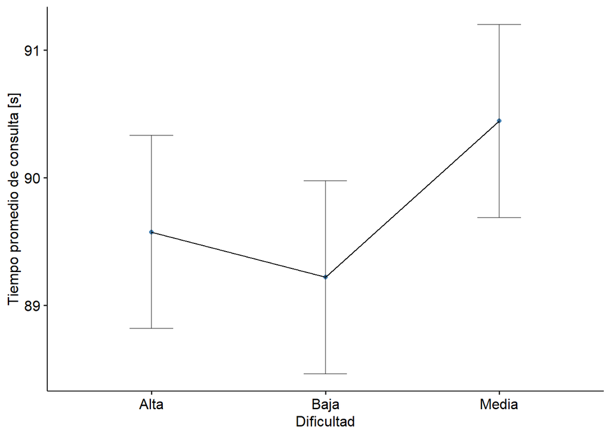

```r
g2 <- ezPlot ( data = data_filter , dv = tiempo , wid = id, within = dificultad,
y_lab = " Tiempo promedio de consulta [s] ", x_lab= "Dificultad",x = dificultad )
g2 <- g2 + theme_pubr()
g2 [["layers"]][[1]][["aes_params"]][["colour"]] <- "steelblue"
print(g2)
```

Según el gráfico, el tiempo promedio de consulta en la dificultad Media en el área de Economía es mayor a la dificultad Alta y Baja, mientras que los tiempos promedios en las dificultades Alta y Baja se acercan bastante.

Ahora para la prueba Post-Hoc se calculara y contrastaran las Medias Marginales Estimadas (EMM):

```r
#Se calculan las medias marginales estimadas

modelo_aov <- aov(tiempo ~ dificultad + Error(id/dificultad), data = data_filter)
medias_estimadas <- emmeans(modelo_aov, ~dificultad)
```

```
## Note: re-fitting model with sum-to-zero contrasts
```

```
## NOTE: Results are based on intra-block estimates and are biased.
```

```r
print(summary( medias_estimadas , infer = TRUE , level = 1 - 0.01 , null=mean (data_filter[["tiempo"]])))
```

```
##  dificultad emmean    SE  df lower.CL upper.CL null t.ratio p.value
##  Alta         88.7 0.929 524     86.3     91.1 89.7  -1.168  0.2434
##  Baja         89.4 0.929 524     87.0     91.8 89.7  -0.397  0.6919
##  Media        91.2 0.929 524     88.8     93.6 89.7   1.564  0.1183
##
## Warning: EMMs are biased unless design is perfectly balanced
## Confidence level used: 0.99
```

Ya con las medias marginales estimadas se realiza una prueba HSD de Tukey, al ser una prueba hecha específicamente para el test ANOVA, con datos simples (3 grupos de dificultad), comparación únicamente por pares, y al saber ya que no hay diferencias significativas, no se necesita hacer contrastes complejos.

Para realizarla se deben cumplir los supuestos:

- Se verifican las condiciones para realizar la prueba Anova: esto ya se realizó anteriormente por lo que se cumple.
- Los grupos tienen la misma cantidad de observaciones: todos los participantes realizan las 3 dificultades por lo que todas las dificultades tienen la misma cantidad de observaciones.

Ya con eso realizado se realiza la prueba HSD de Tukey:

```r
scheffe <- contrast(medias_estimadas, method="pairwise", level=1-0.01, adjust="tukey")
print(summary(scheffe, infer=TRUE))
```

```
##  contrast     estimate  SE  df lower.CL upper.CL t.ratio p.value
##  Alta - Baja    -0.716 1.6 594    -5.38     3.95  -0.449  0.8948
##  Alta - Media   -2.538 1.6 594    -7.20     2.13  -1.591  0.2504
##  Baja - Media   -1.822 1.6 594    -6.49     2.84  -1.142  0.4887
##
## Confidence level used: 0.99
## Conf-level adjustment: tukey method for comparing a family of 3 estimates
## P value adjustment: tukey method for comparing a family of 3 estimates
```

Según los resultados dados, se puede ver las comparaciones de pares de dificultades, en las cuales no hay diferencias significativas, tal como la conclusión a la que se llegó en el test ANOVA para muestras correlacionadas, así mismo la mayor diferencia es entre las dificultades Alta y Media, y la menor diferencia entre las dificultades Alta y Baja.

## Conclusiones

Con los resultados del test ANOVA para muestras correlacionadas, y el prueba Post-Hoc que confirma lo obtenido en el test ANOVA, se puede concluir que no hay evidencia suficiente para rechazar el que no haya diferencia significativa en el tiempo que tardan los usuarios en formular consultas con un 99% de confianza.